# Evaluating Biomass Change: Regression Analysis and Diagnostics in Fish Forever Areas

Mariano Viz

2024-10-14

```r
# Read in Data
ma <- read_excel(here("data", "raw","Aggregated Data.xlsx"), sheet = "MA - Biomass by year")
reserve <- read_excel(here("data", "raw","Aggregated Data.xlsx"), sheet = "Reserve - Biomass by year")

# Filter out sites with only one observation
ma <- ma %>%
  group_by(ma_name) %>%
  filter(n() > 1) %>%
  ungroup()

reserve <- reserve %>%
  group_by(ma_name) %>%
  filter(n() > 1) %>%
  ungroup()
```

## Summary

This document recreates the linear regression models initially conducted on biomass change over time in various Fish Forever Managed Access and Reserve Areas. In the first part of each section, the original regression analyses are replicated, and the results, including the regression equations, match the previous findings. Following this, I evaluate the diagnostic plots and model fit for each of the models.

The conclusions drawn from these evaluations across the different analyses are quite similar:

- **Model Fit**: Across all the models, the R-squared values are relatively low, indicating that a small percentage of the variance in biomass change is explained by the `years_from_baseline` variable. This suggests that other important factors affecting biomass change are missing from the models.
- **Outliers**: Several outliers or influential points are identified in each analysis, significantly impacting the model fit. These points are observed in leverage plots and residual diagnostics, suggesting the need for further investigation.
- **Non-linearity and Heteroscedasticity**: The diagnostic plots consistently show evidence of non-linearity and heteroscedasticity. In the residual plots, non-random patterns and increasing spread of residuals with fitted values indicate that the linear model does not fully capture the relationship between the variables, and that the variance in the residuals changes as the fitted values increase.

**Recommendations**:

Given the recurring patterns across the analyses, to improve the quality of the analysis, I recommend the following:

- **Consider Non-Linear Models**: Given the evidence of non-linearity, using non-linear regression models or transforming variables might better capture the underlying relationships in the data.
- **Include Additional Predictors**: The consistently low R-squared values suggest that more relevant predictors should be included to better explain the changes in biomass, such as the size of the Reserves and Managed Access areas.
- **Investigate Outliers**: The influential points and outliers should be further examined to determine if they are valid observations or if adjustments need to be made to account for them.
- **Address Heteroscedasticity**: The heteroscedasticity in the models could be addressed by using weighted least squares or variable transformations to stabilize the variance of the residuals.

By addressing these common issues, the overall model performance and the explanatory power of the analyses in these Fish Forever areas can be improved, providing more reliable insights into the factors influencing biomass changes in these locations.

## Managed Access Areas

### 1. MA (All Countries)

#### 1.1. Linear Regression Analysis

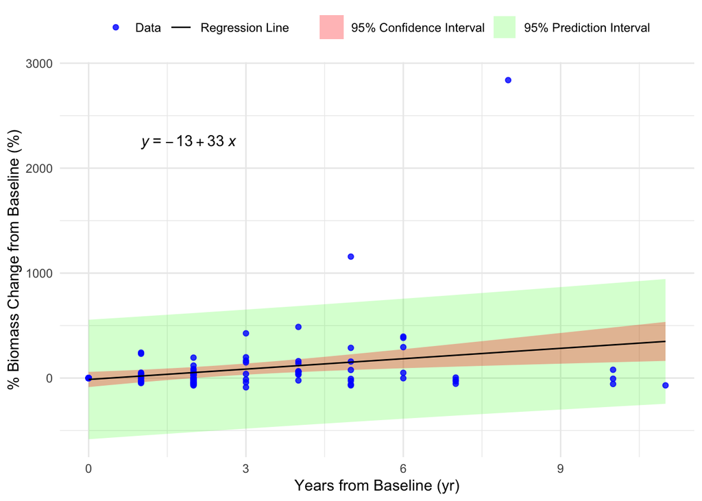

```r
# Linear regression:
ma_all_lm <- lm(percentage_biomass_change_from_baseline ~ years_from_baseline, data = ma)
# Create a data frame with predictions and prediction intervals:
new_data <- ma %>%
  mutate(pred = predict(ma_all_lm, newdata = ma),
         pred_interval = predict(ma_all_lm, newdata = ma, interval = "prediction"))
# Separate out the lower and upper bounds of the prediction interval:
new_data <- new_data %>%
  mutate(lower_bound = pred_interval[, "lwr"],
         upper_bound = pred_interval[, "upr"])

# Plot + prediction interval:
ggplot(data = new_data, aes(x = years_from_baseline, y = percentage_biomass_change_from_baseline)) +
  geom_ribbon(aes(ymin = lower_bound, ymax = upper_bound, fill = "95% Prediction Interval"), alpha = 0.2) +
  geom_smooth(method = "lm", aes(fill = "95% Confidence Interval"), color = NA, size = 0.5, alpha = 0.3) +
  geom_point(aes(color = "Data"), alpha = 0.8) +
  geom_smooth(method = "lm", aes(color = "Regression Line"), size = 0.5, se = FALSE) +
  theme_minimal() +
  ggpubr::stat_regline_equation(label.x = 1, label.y = 2250) +
  labs(x = "Years from Baseline (yr)",
       y = "% Biomass Change from Baseline (%)") +
  scale_color_manual(name = NULL,
                     values = c("Data" = "blue", "Regression Line" = "black")) +
  scale_fill_manual(name = NULL,
                    values = c("95% Confidence Interval" = "red", "95% Prediction Interval" = "green")) +
  guides(fill = guide_legend(override.aes = list(color = NA)),
         color = guide_legend(override.aes = list(fill = NA))) +
  theme(legend.position = "top")
```

#### 1.2. Diagnostic Plots

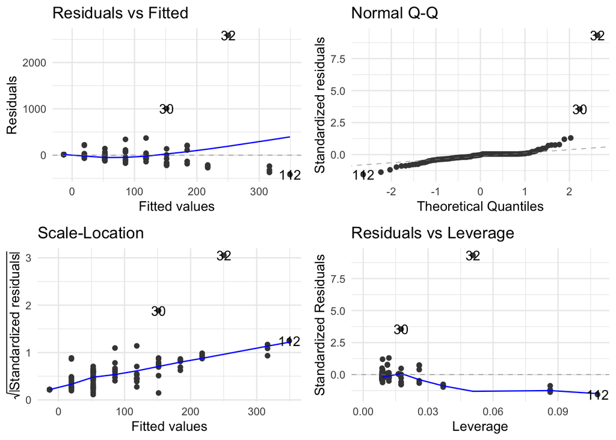

```r
# Linear regression:
ma_all_lm <- lm(percentage_biomass_change_from_baseline ~ years_from_baseline, data = ma)

#Model diagnostics:
# plot(ma_all_lm)
autoplot(ma_all_lm) +
  theme_minimal()
```

**Residuals vs Fitted Plot (Top Left)**: The residuals should be randomly scattered around the horizontal line (i.e., residuals = 0) if the linear model is appropriate. Here, residuals show some non-random patterns, and there seems to be a slight curvature, which might indicate non-linearity. Also, the spread of the residuals increases slightly as fitted values increase, suggesting heteroscedasticity (non-constant variance).

**Scale-Location Plot (Bottom Left)**: Ideally, the blue line should be horizontal, and the points should be randomly scattered around it. In this plot, the spread of points increases with the fitted values, as indicated by the upward-sloping line, suggesting heteroscedasticity. This confirms the impression from the Residuals vs Fitted plot.

**Summary**:

#### 1.3. Model Summary

```r
# Tidy versions of the model output for in-line referencing:
ma_all_lm_tidy <- tidy(ma_all_lm)
ma_all_lm_glance <- glance(ma_all_lm)
#R^2 * 100 (for in-referencing as a percent):
ma_all_rsq_perc <- ma_all_lm_glance$r.squared*100
# Pearson's r correlation:
ma_all_cor <- cor.test(ma$percentage_biomass_change_from_baseline, ma$years_from_baseline)
# Tidy versions of correlation output for in-line referencing:
ma_all_cor_tidy <- tidy(ma_all_cor)


# Tables:
# Get the summary of the model
ma_all_lm_summary <- summary(ma_all_lm)
# Extract coefficients
coef_table <- as.data.frame(ma_all_lm_summary$coefficients)
# Extract R-squared and Adjusted R-squared
r_squared <- ma_all_lm_summary$r.squared
adj_r_squared <- ma_all_lm_summary$adj.r.squared
# Extract F-statistic and p-value
f_statistic <- ma_all_lm_summary$fstatistic[1]
p_value <- pf(f_statistic, ma_all_lm_summary$fstatistic[2], ma_all_lm_summary$fstatistic[3], lower.tail = FALSE)
# Extract Residual Standard Error
residual <- ma_all_lm_summary$sigma


# Display coefficients in a neat table
kable(coef_table, caption = "Coefficients from the Linear Model")
```

Coefficients from the Linear Model

|  | Estimate | Std. Error | t value | Pr(>\|t\|) |
| --- | --- | --- | --- | --- |
| (Intercept) | -13.43469 | 36.46891 | -0.3683876 | 0.7132557 |
| years_from_baseline | 32.98032 | 10.48701 | 3.1448725 | 0.0021108 |

```r
# Create a summary statistics table
model_summary <- data.frame(
  Statistic = c("Residual Standard Error","R-squared", "Adjusted R-squared", "F-statistic", "p-value"),
  Value = c(residual, r_squared, adj_r_squared, f_statistic, p_value)
)
# Display the model summary
kable(model_summary, caption = "Model Summary Statistics")
```

Model Summary Statistics

| Statistic | Value |
| --- | --- |
| Residual Standard Error | 285.0177348 |
| R-squared | 0.0785623 |
| Adjusted R-squared | 0.0706189 |
| F-statistic | 9.8902229 |
| p-value | 0.0021108 |

**Summary**:

- The `years_from_baseline` variable has a **statistically significant positive effect** on the percentage biomass change from baseline, with a 33% increase for every additional year.
- However, **the overall model fit is relatively weak**, as indicated by the low R-squared values. This suggests that while `years_from_baseline` is a significant predictor, there are other factors affecting biomass change that are not included in the model.

### 2. MA (All Countries - except Culasi)

#### 2.1. Linear Regression Analysis

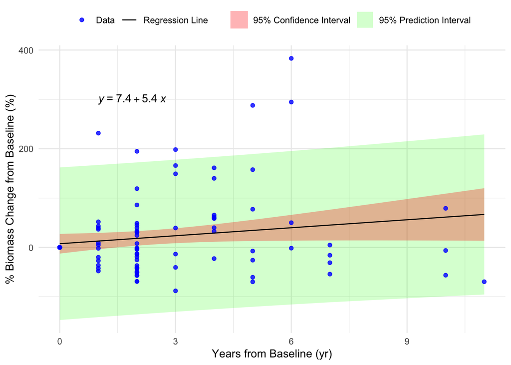

```r
# Linear regression:
ma_cul <- ma %>%
  filter(ma_name != "Culasi")
ma_cul_lm <- lm(percentage_biomass_change_from_baseline ~ years_from_baseline, data = ma_cul)
# Create a data frame with predictions and prediction intervals:
new_data_cul <- ma_cul %>%
  mutate(pred = predict(ma_cul_lm, newdata = ma_cul),
         pred_interval = predict(ma_cul_lm, newdata = ma_cul, interval = "prediction"))
# Separate out the lower and upper bounds of the prediction interval:
new_data_cul <- new_data_cul %>%
  mutate(lower_bound = pred_interval[, "lwr"],
         upper_bound = pred_interval[, "upr"])

# Plot + prediction interval:
ggplot(data = new_data_cul, aes(x = years_from_baseline, y = percentage_biomass_change_from_baseline)) +
  geom_ribbon(aes(ymin = lower_bound, ymax = upper_bound, fill = "95% Prediction Interval"), alpha = 0.2) +
  geom_smooth(method = "lm", aes(fill = "95% Confidence Interval"), color = NA, size = 0.5, alpha = 0.3) +
  geom_point(aes(color = "Data"), alpha = 0.8) +
  geom_smooth(method = "lm", aes(color = "Regression Line"), size = 0.5, se = FALSE) +
  theme_minimal() +
  ggpubr::stat_regline_equation(label.x = 1, label.y = 300) +
  labs(x = "Years from Baseline (yr)",
       y = "% Biomass Change from Baseline (%)") +
  scale_color_manual(name = NULL,
                     values = c("Data" = "blue", "Regression Line" = "black")) +
  scale_fill_manual(name = NULL,
                    values = c("95% Confidence Interval" = "red", "95% Prediction Interval" = "green")) +
  guides(fill = guide_legend(override.aes = list(color = NA)),
         color = guide_legend(override.aes = list(fill = NA))) +
  theme(legend.position = "top")
```

#### 2.2. Diagnostic Plots

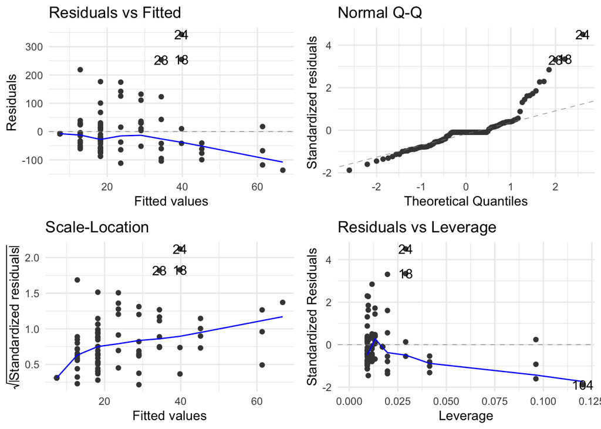

```r
# Linear regression:
ma_cul_lm <- lm(percentage_biomass_change_from_baseline ~ years_from_baseline, data = ma_cul)

#Model diagnostics:
# plot(ma_all_lm)
autoplot(ma_cul_lm) +
  theme_minimal()
```

**Residuals vs Fitted Plot (Top Left)**: The residuals show some non-random patterns, with slight curvature, indicating potential non-linearity. The spread of the residuals also increases slightly with fitted values, suggesting heteroscedasticity.

**Scale-Location Plot (Bottom Left)**: The upward-sloping blue line, along with the increasing spread of points, suggests the presence of heteroscedasticity, confirming what was observed in the Residuals vs Fitted plot.

**Summary**:

#### 2.3. Model Summary

```r
# Tables:
# Get the summary of the model
ma_cul_lm_summary <- summary(ma_cul_lm)
# Extract coefficients
coef_table_cul <- as.data.frame(ma_cul_lm_summary$coefficients)
# Extract R-squared and Adjusted R-squared
r_squared_cul <- ma_cul_lm_summary$r.squared
adj_r_squared_cul <- ma_cul_lm_summary$adj.r.squared
# Extract F-statistic and p-value
f_statistic_cul <- ma_cul_lm_summary$fstatistic[1]
p_value_cul <- pf(f_statistic_cul, ma_cul_lm_summary$fstatistic[2], ma_cul_lm_summary$fstatistic[3], lower.tail = FALSE)
# Display coefficients in a neat table
kable(coef_table_cul, caption = "Coefficients from the Linear Model")
```

Coefficients from the Linear Model

|  | Estimate | Std. Error | t value | Pr(>\|t\|) |
| --- | --- | --- | --- | --- |
| (Intercept) | 7.435237 | 10.115067 | 0.7350655 | 0.4638928 |
| years_from_baseline | 5.391535 | 2.974552 | 1.8125536 | 0.0726788 |

```r
# Extract Residual Standard Error
residual_cul <- ma_cul_lm_summary$sigma

# Create a summary statistics table
model_summary_cul <- data.frame(
  Statistic = c("Residual Standard Error", "R-squared", "Adjusted R-squared", "F-statistic", "p-value"),
  Value = c(residual_cul, r_squared_cul, adj_r_squared_cul, f_statistic_cul, p_value_cul)
)
# Display the model summary
kable(model_summary_cul, caption = "Model Summary Statistics")
```

Model Summary Statistics

| Statistic | Value |
| --- | --- |
| Residual Standard Error | 77.3508273 |
| R-squared | 0.0295219 |
| Adjusted R-squared | 0.0205360 |
| F-statistic | 3.2853505 |
| p-value | 0.0726788 |

```r
#summary(ma_cul_lm)
```

**Coefficients**:

- **Intercept**: The intercept is 7.43, with a p-value of 0.46, indicating that it is not statistically significant (i.e., the intercept does not contribute meaningfully to the model).
- `years_from_baseline`: The coefficient for `years_from_baseline` is 5.39, and the p-value is not significant at the 0.05 level (p = 0.07). This means that for every additional year from the baseline, the percentage change in biomass is expected to increase by approximately 5.39%, but this effect is not statistically significant at the 0.05 level (p = 0.07).

**Model Fit**:

- **Residual standard error**: The residual standard error is 77.35, which is relatively lower, indicating a better fit compared to the previous model.
- **Multiple R-squared**: The R-squared value is 0.029, meaning only 2.9% of the variance in biomass change is explained by years_from_baseline, suggesting a weak fit.
- **Adjusted R-squared**: The adjusted R-squared is 0.02, which is similar to the multiple R-squared, confirming limited explanatory power.
- **F-statistic**: The F-statistic is 3.28 with a p-value of 0.07, meaning the overall model is not statistically significant at the 0.05 level.

**Summary**:

- In this model, the `years_from_baseline` variable **does not have a statistically significant effect** on the percentage biomass change.
- The **overall model fit is weak**.

### 3. MA (Philipinnes - except Culasi)

#### 3.1. Linear Regression Analysis

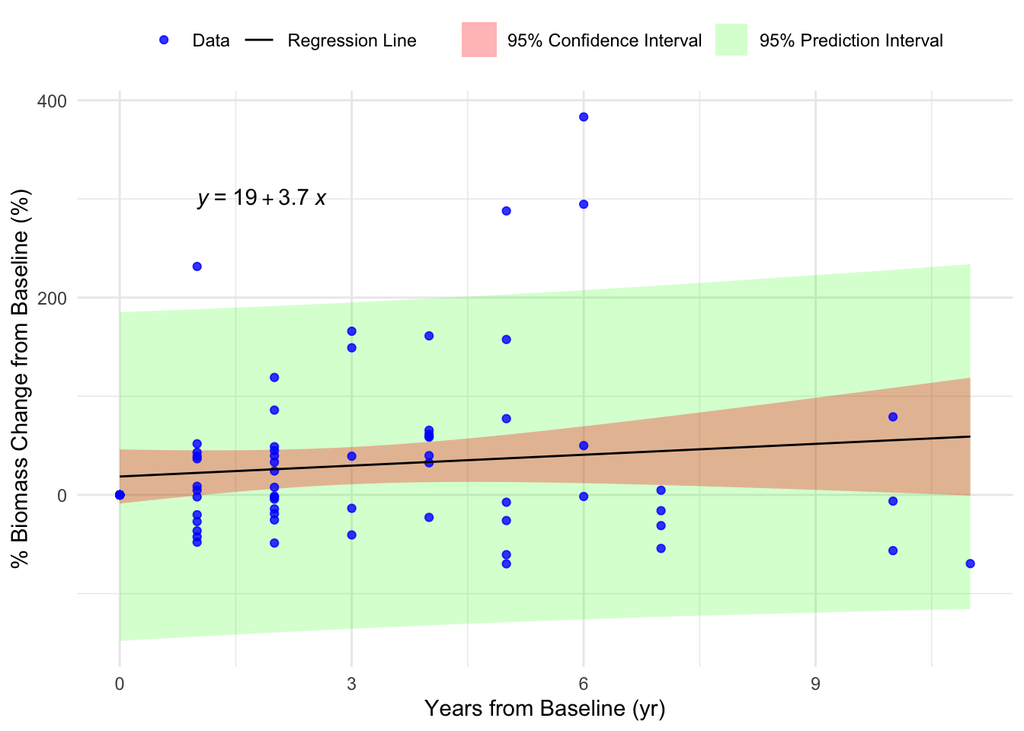

```r
# Linear regression:
ma_cul_phi <- ma_cul %>%
  filter(country == "Philippines")
ma_cul_phi_lm <- lm(percentage_biomass_change_from_baseline ~ years_from_baseline, data = ma_cul_phi)
# Create a data frame with predictions and prediction intervals:
new_data_cul_phi <- ma_cul_phi %>%
  mutate(pred = predict(ma_cul_phi_lm, newdata = ma_cul_phi),
         pred_interval = predict(ma_cul_phi_lm, newdata = ma_cul_phi, interval = "prediction"))
# Separate out the lower and upper bounds of the prediction interval:
new_data_cul_phi <- new_data_cul_phi %>%
  mutate(lower_bound = pred_interval[, "lwr"],
         upper_bound = pred_interval[, "upr"])

# Plot + prediction interval:
ggplot(data = new_data_cul_phi, aes(x = years_from_baseline, y = percentage_biomass_change_from_baseline)) +
  geom_ribbon(aes(ymin = lower_bound, ymax = upper_bound, fill = "95% Prediction Interval"), alpha = 0.2) +
  geom_smooth(method = "lm", aes(fill = "95% Confidence Interval"), color = NA, size = 0.5, alpha = 0.3) +
  geom_point(aes(color = "Data"), alpha = 0.8) +
  geom_smooth(method = "lm", aes(color = "Regression Line"), size = 0.5, se = FALSE) +
  theme_minimal() +
  ggpubr::stat_regline_equation(label.x = 1, label.y = 300) +
  labs(x = "Years from Baseline (yr)",
       y = "% Biomass Change from Baseline (%)") +
  scale_color_manual(name = NULL,
                     values = c("Data" = "blue", "Regression Line" = "black")) +
  scale_fill_manual(name = NULL,
                    values = c("95% Confidence Interval" = "red", "95% Prediction Interval" = "green")) +
  guides(fill = guide_legend(override.aes = list(color = NA)),
         color = guide_legend(override.aes = list(fill = NA))) +
  theme(legend.position = "top")
```

#### 3.2. Diagnostic Plots

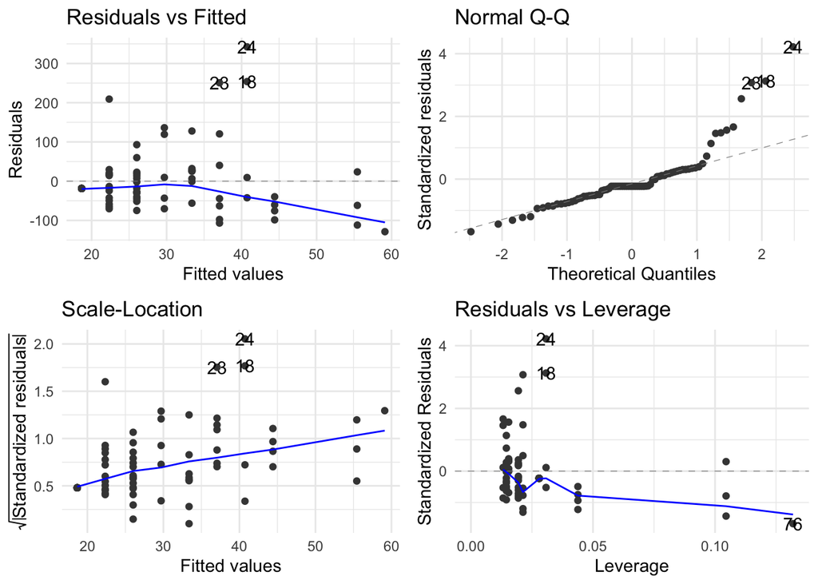

```r
# Linear regression:
ma_cul_phi_lm <- lm(percentage_biomass_change_from_baseline ~ years_from_baseline, data = ma_cul_phi)

#Model diagnostics:
# plot(ma_all_lm)
autoplot(ma_cul_phi_lm) +
  theme_minimal()
```

**Residuals vs Fitted Plot (Top Left)**: The residuals show some non-random patterns, with a slight downward curvature, suggesting potential non-linearity. There is also a mild indication of heteroscedasticity, as the spread of residuals increases slightly at higher fitted values.

**Scale-Location Plot (Bottom Left)**: The blue line slopes upwards, and the points fan out slightly, confirming the presence of heteroscedasticity, where the variability of residuals increases with fitted values.

**Summary**:

#### 3.3. Model Summary

```r
# Tables:
# Get the summary of the model
ma_cul_phi_lm_summary <- summary(ma_cul_phi_lm)
# Extract coefficients
coef_table_cul_phi <- as.data.frame(ma_cul_phi_lm_summary$coefficients)
# Extract R-squared and Adjusted R-squared
r_squared_cul_phi <- ma_cul_phi_lm_summary$r.squared
adj_r_squared_cul_phi <- ma_cul_phi_lm_summary$adj.r.squared
# Extract F-statistic and p-value
f_statistic_cul_phi <- ma_cul_phi_lm_summary$fstatistic[1]
p_value_cul_phi <- pf(f_statistic_cul_phi, ma_cul_phi_lm_summary$fstatistic[2], ma_cul_phi_lm_summary$fstatistic[3], lower.tail = FALSE)
# Display coefficients in a neat table
kable(coef_table_cul_phi, caption = "Coefficients from the Linear Model")
```

Coefficients from the Linear Model

|  | Estimate | Std. Error | t value | Pr(>\|t\|) |
| --- | --- | --- | --- | --- |
| (Intercept) | 18.665233 | 13.780940 | 1.354424 | 0.1797225 |
| years_from_baseline | 3.677442 | 3.494434 | 1.052371 | 0.2960536 |

```r
# Extract Residual Standard Error
residual_cul_phi <- ma_cul_phi_lm_summary$sigma

# Create a summary statistics table
model_summary_cul_phi <- data.frame(
  Statistic = c("Residual Standard Error", "R-squared", "Adjusted R-squared", "F-statistic", "p-value"),
  Value = c(residual_cul_phi, r_squared_cul_phi, adj_r_squared_cul_phi, f_statistic_cul_phi, p_value_cul_phi)
)
# Display the model summary
kable(model_summary_cul_phi, caption = "Model Summary Statistics")
```

Model Summary Statistics

| Statistic | Value |
| --- | --- |
| Residual Standard Error | 82.4482309 |
| R-squared | 0.0147453 |
| Adjusted R-squared | 0.0014311 |
| F-statistic | 1.1074853 |
| p-value | 0.2960536 |

```r
#summary(ma_cul_phi_lm)
```

**Coefficients**:

- **Intercept**: The intercept is 18.66, with a p-value of 0.17, indicating that it is not statistically significant. This means the intercept does not contribute meaningfully to the model.
- `years_from_baseline`: The coefficient for `years_from_baseline` is 3.67, with a p-value of 0.29, which is also not statistically significant. This suggests that `years_from_baseline` does not have a significant effect on the percentage biomass change in this model.

**Summary**:

- In this model, the `years_from_baseline` variable **does not have a statistically significant effect** on the percentage biomass change.
- The **model fit is very weak**, explaining only a minimal portion of the variability in biomass change.

## Reserve Areas

### 1. Reserve Areas (All Countries)

#### 1.1. Linear Regression Analysis

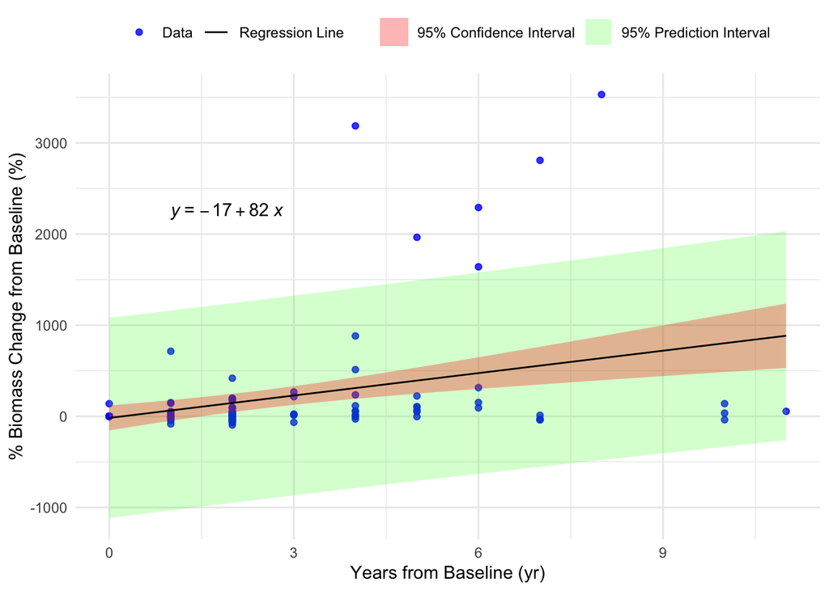

```r
# Linear regression:
reserve_lm <- lm(percentage_biomass_change_from_baseline ~ years_from_baseline, data = reserve)
# Create a data frame with predictions and prediction intervals:
new_data_reserve <- reserve %>%
  mutate(pred = predict(reserve_lm, newdata = reserve),
         pred_interval = predict(reserve_lm, newdata = reserve, interval = "prediction"))
# Separate out the lower and upper bounds of the prediction interval:
new_data_reserve <- new_data_reserve %>%
  mutate(lower_bound = pred_interval[, "lwr"],
         upper_bound = pred_interval[, "upr"])

# Plot + prediction interval:
ggplot(data = new_data_reserve, aes(x = years_from_baseline, y = percentage_biomass_change_from_baseline)) +
  geom_point(aes(color = "Data"), alpha = 0.8) +
  geom_ribbon(aes(ymin = lower_bound, ymax = upper_bound, fill = "95% Prediction Interval"), alpha = 0.2) +
  geom_smooth(method = "lm", aes(fill = "95% Confidence Interval"), color = NA, size = 0.5, alpha = 0.3) +
  geom_smooth(method = "lm", aes(color = "Regression Line"), size = 0.5, se = FALSE) +
  theme_minimal() +
  ggpubr::stat_regline_equation(label.x = 1, label.y = 2250) +
  labs(x = "Years from Baseline (yr)",
       y = "% Biomass Change from Baseline (%)") +
  scale_color_manual(name = NULL,
                     values = c("Data" = "blue", "Regression Line" = "black")) +
  scale_fill_manual(name = NULL,
                    values = c("95% Confidence Interval" = "red", "95% Prediction Interval" = "green")) +
  guides(fill = guide_legend(override.aes = list(color = NA)),
         color = guide_legend(override.aes = list(fill = NA))) +
  theme(legend.position = "top")
```

#### 1.2. Diagnostic Plots

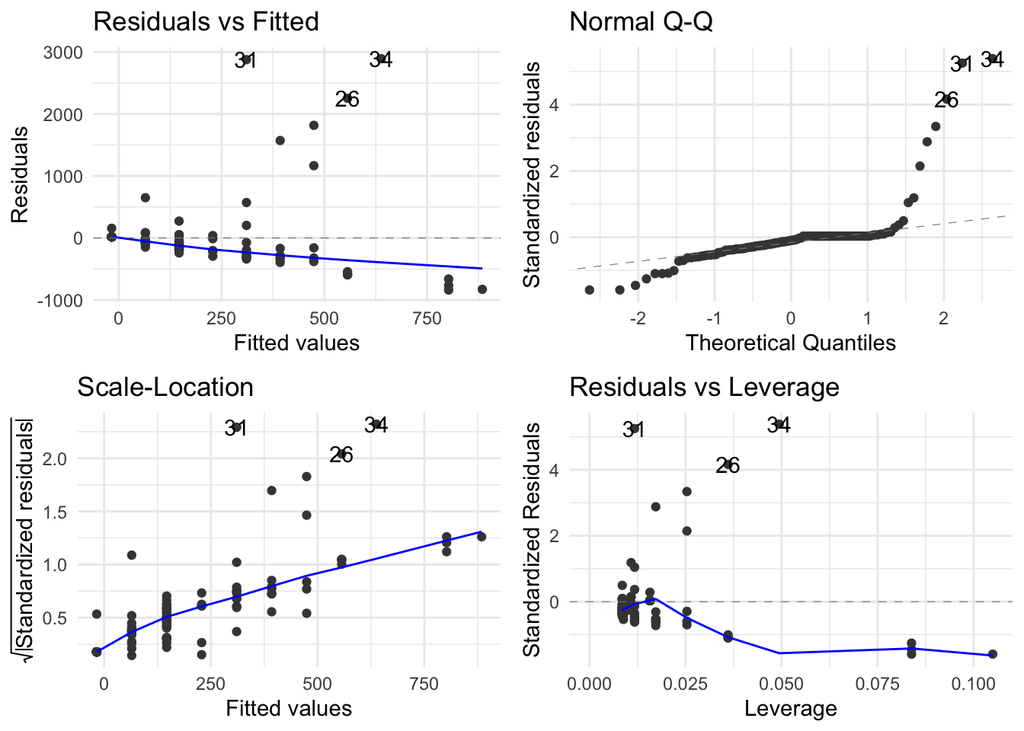

```r
# Linear regression:
reserve_lm <- lm(percentage_biomass_change_from_baseline ~ years_from_baseline, data = reserve)

#Model diagnostics:
# plot(ma_all_lm)
autoplot(reserve_lm) +
  theme_minimal()
```

**Residuals vs Fitted Plot (Top Left)**: There is a slight curvature in the residuals, indicating potential non-linearity. Additionally, the spread of residuals increases at higher fitted values, suggesting heteroscedasticity.

**Scale-Location Plot (Bottom Left)**: The upward-sloping blue line indicates increasing variability in residuals as fitted values increase, confirming heteroscedasticity.

**Summary**:

#### 1.3. Model Summary

```r
# Tables:
# Get the summary of the model
reserve_lm_summary <- summary(reserve_lm)
# Extract coefficients
coef_table_res <- as.data.frame(reserve_lm_summary$coefficients)
# Extract R-squared and Adjusted R-squared
r_squared_res <- reserve_lm_summary$r.squared
adj_r_squared_res <- reserve_lm_summary$adj.r.squared
# Extract F-statistic and p-value
f_statistic_res <- reserve_lm_summary$fstatistic[1]
p_value_res <- pf(f_statistic_res, reserve_lm_summary$fstatistic[2], reserve_lm_summary$fstatistic[3], lower.tail = FALSE)
# Extract Residual Standard Error
residual_res <- reserve_lm_summary$sigma

# Display coefficients in a neat table
kable(coef_table_res, caption = "Coefficients from the Linear Model")
```

Coefficients from the Linear Model

|  | Estimate | Std. Error | t value | Pr(>\|t\|) |
| --- | --- | --- | --- | --- |
| (Intercept) | -17.42956 | 69.08570 | -0.252289 | 0.8012566 |
| years_from_baseline | 81.96075 | 19.87444 | 4.123928 | 0.0000696 |

```r
# Create a summary statistics table
model_summary_res <- data.frame(
  Statistic = c("Residual Standard Error", "R-squared", "Adjusted R-squared", "F-statistic", "p-value"),
  Value = c(residual_res, r_squared_res, adj_r_squared_res, f_statistic_res, p_value_res)
)
# Display the model summary
kable(model_summary_res, caption = "Model Summary Statistics")
```

Model Summary Statistics

| Statistic | Value |
| --- | --- |
| Residual Standard Error | 550.9079870 |
| R-squared | 0.1259699 |
| Adjusted R-squared | 0.1185628 |
| F-statistic | 17.0067858 |
| p-value | 0.0000696 |

```r
#summary(reserve_lm)
```

**Coefficients**:

- **Intercept**: The intercept is -17.42, with a p-value of 0.8, indicating that it is not statistically significant. This suggests that the intercept does not meaningfully contribute to the model.
- `years_from_baseline`: The coefficient for `years_from_baseline` is 81.96, and it is highly significant, with a p-value of 6.9e-05. This suggests that for each additional year from baseline, the percentage biomass change is expected to increase by 81.96%, and this effect is statistically significant.

**Model Fit**:

- **Residual standard error**: The residual standard error is 550.9, indicating that the actual values deviate substantially from the predicted values, suggesting a less precise model fit.
- **Multiple R-squared**: The R-squared value is 0.125, indicating that about 12.5% of the variance in percentage biomass change can be explained by years_from_baseline. This is a modest fit, meaning that other factors likely affect biomass change.
- **Adjusted R-squared**: The adjusted R-squared is 0.11, confirming that the model explains some variability, but the explanatory power remains relatively low.
- **F-statistic**: The F-statistic is 17, with a highly significant p-value of 6.9e-05. This indicates that the overall model is statistically significant, meaning the years_from_baseline variable is a meaningful predictor of biomass change.

**Summary**:

- The `years_from_baseline` variable has a **statistically significant positive effect** on the percentage biomass change, with an 81.96% increase for each additional year.
- The **model fit is still moderate**, as indicated by the relatively low R-squared values, suggesting other factors not included in the model may be influencing biomass change.

### 2. Reserve Areas (All Countries - except Cortes)

#### 2.1. Linear Regression Analysis

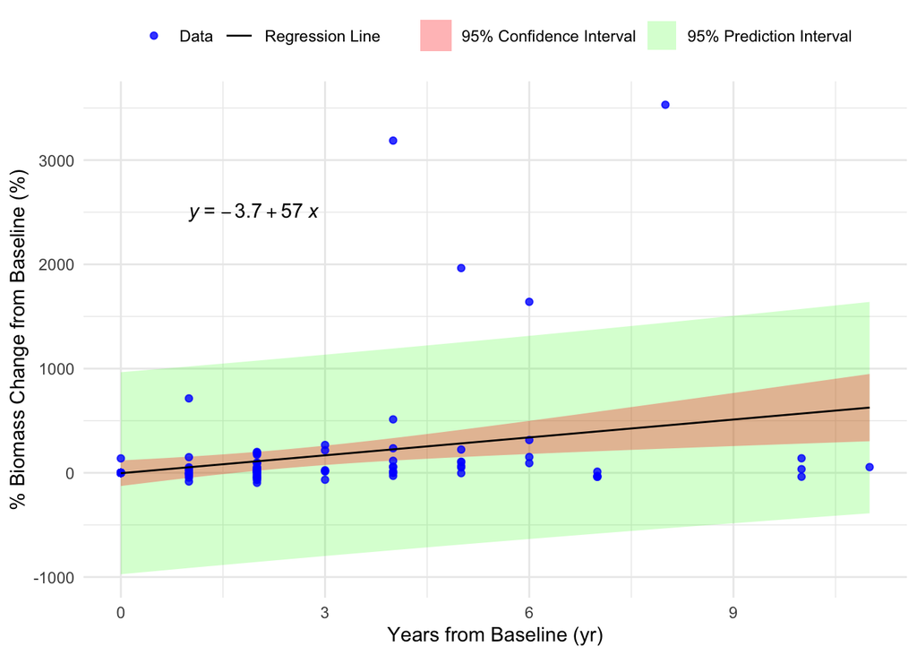

```r
# Linear regression:
reserve_cor <- reserve %>%
  filter(ma_name != "Cortes")
reserve_cor_lm <- lm(percentage_biomass_change_from_baseline ~ years_from_baseline, data = reserve_cor)
# Create a data frame with predictions and prediction intervals:
new_data_reserve_cor <- reserve_cor %>%
  mutate(pred = predict(reserve_cor_lm, newdata = reserve_cor),
         pred_interval = predict(reserve_cor_lm, newdata = reserve_cor, interval = "prediction"))
# Separate out the lower and upper bounds of the prediction interval:
new_data_reserve_cor <- new_data_reserve_cor %>%
  mutate(lower_bound = pred_interval[, "lwr"],
         upper_bound = pred_interval[, "upr"])

# Plot + prediction interval:
ggplot(data = new_data_reserve_cor, aes(x = years_from_baseline, y = percentage_biomass_change_from_baseline)) +
  geom_ribbon(aes(ymin = lower_bound, ymax = upper_bound, fill = "95% Prediction Interval"), alpha = 0.2) +
  geom_smooth(method = "lm", aes(fill = "95% Confidence Interval"), color = NA, size = 0.5, alpha = 0.3) +
  geom_point(aes(color = "Data"), alpha = 0.8) +
  geom_smooth(method = "lm", aes(color = "Regression Line"), size = 0.5, se = FALSE) +
  theme_minimal() +
  ggpubr::stat_regline_equation(label.x = 1, label.y = 2500) +
  labs(x = "Years from Baseline (yr)",
       y = "% Biomass Change from Baseline (%)") +
  scale_color_manual(name = NULL,
                     values = c("Data" = "blue", "Regression Line" = "black")) +
  scale_fill_manual(name = NULL,
                    values = c("95% Confidence Interval" = "red", "95% Prediction Interval" = "green")) +
  guides(fill = guide_legend(override.aes = list(color = NA)),
         color = guide_legend(override.aes = list(fill = NA))) +
  theme(legend.position = "top")
```

#### 2.2. Diagnostic Plots

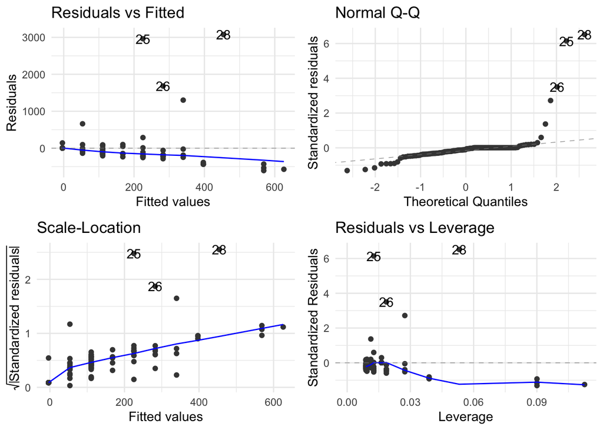

```r
# Linear regression:
reserve_cor_lm <- lm(percentage_biomass_change_from_baseline ~ years_from_baseline, data = reserve_cor)

#Model diagnostics:
# plot(ma_all_lm)
autoplot(reserve_cor_lm) +
  theme_minimal()
```

**Residuals vs Fitted Plot (Top Left)**: There is some slight curvature, suggesting potential non-linearity. The spread of residuals increases slightly at higher fitted values, indicating possible heteroscedasticity.

**Scale-Location Plot (Bottom Left)**: The blue line slopes upwards, and the spread of points increases, confirming heteroscedasticity with increasing fitted values.

**Summary**:

#### 2.3. Model Summary

```r
# Tables:
# Get the summary of the model
reserve_cor_lm_summary <- summary(reserve_cor_lm)
# Extract coefficients
coef_table_res_cor <- as.data.frame(reserve_cor_lm_summary$coefficients)
# Extract R-squared and Adjusted R-squared
r_squared_res_cor <- reserve_cor_lm_summary$r.squared
adj_r_squared_res_cor <- reserve_cor_lm_summary$adj.r.squared
# Extract F-statistic and p-value
f_statistic_res_cor <- reserve_cor_lm_summary$fstatistic[1]
p_value_res_cor <- pf(f_statistic_res_cor, reserve_cor_lm_summary$fstatistic[2], reserve_cor_lm_summary$fstatistic[3], lower.tail = FALSE)
# Extract Residual Standard Error
residual_res_cor <- reserve_cor_lm_summary$sigma

# Display coefficients in a neat table
kable(coef_table_res_cor, caption = "Coefficients from the Linear Model")
```

Coefficients from the Linear Model

|  | Estimate | Std. Error | t value | Pr(>\|t\|) |
| --- | --- | --- | --- | --- |
| (Intercept) | -3.657873 | 61.94346 | -0.0590518 | 0.9530161 |
| years_from_baseline | 57.225945 | 18.04049 | 3.1720844 | 0.0019533 |

```r
# Create a summary statistics table
model_summary_res_cor <- data.frame(
  Statistic = c("Residual Standard Error", "R-squared", "Adjusted R-squared", "F-statistic", "p-value"),
  Value = c(residual_res_cor, r_squared_res_cor, adj_r_squared_res_cor, f_statistic_res_cor, p_value_res_cor)
)
# Display the model summary
kable(model_summary_res_cor, caption = "Model Summary Statistics")
```

Model Summary Statistics

| Statistic | Value |
| --- | --- |
| Residual Standard Error | 485.1962965 |
| R-squared | 0.0824344 |
| Adjusted R-squared | 0.0742419 |
| F-statistic | 10.0621196 |
| p-value | 0.0019533 |

```r
#summary(reserve_cor_lm)
```

**Coefficients**:

- **Intercept**: The intercept is -3.65, with a p-value of 0.95, indicating that it is not statistically significant. This suggests that the intercept does not meaningfully contribute to the model.
- `years_from_baseline`: The coefficient for `years_from_baseline` is 57.22, and it is highly significant, with a p-value of 0.0019. This suggests that for each additional year from baseline, the percentage biomass change is expected to increase by 57.2%, and this effect is statistically significant.

**Model Fit**:

- **Residual standard error**: The residual standard error is 485.19, indicating that the actual values deviate substantially from the predicted values, suggesting a moderate model fit.
- **Multiple R-squared**: The R-squared value is 0.082, indicating that about 8.2% of the variance in percentage biomass change can be explained by years_from_baseline. This is a relatively low value, suggesting that the model only explains a small portion of the variability in biomass change.
- **Adjusted R-squared:** The adjusted R-squared is 0.074, confirming that the model’s explanatory power remains low, even when accounting for the number of predictors.
- **F-statistic**: The F-statistic is 10.06, with a significant p-value of 0.0019. This indicates that the overall model is statistically significant, meaning the `years_from_baseline` variable is a meaningful predictor of biomass change.

**Summary**:

- The `years_from_baseline` variable has a **statistically significant positive effect** on the percentage biomass change, with a 57.2% increase for each additional year.
- **The model fit is weak**, as indicated by the low R-squared values, suggesting that other factors not included in the model may be influencing biomass change.

### 3. Reserve Areas (Philippines - except Cortes)

#### 3.1. Linear Regression Analysis

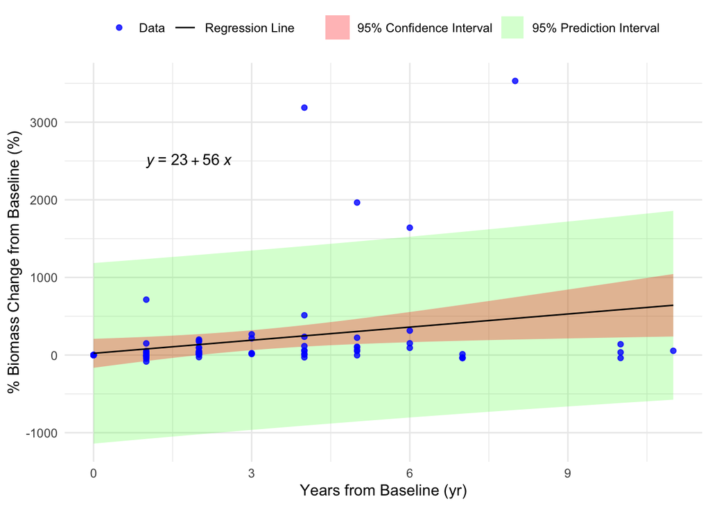

```r
# Linear regression:
reserve_cor_phi <- reserve_cor %>%
  filter(country == "Philippines")
reserve_cor_phi_lm <- lm(percentage_biomass_change_from_baseline ~ years_from_baseline, data = reserve_cor_phi)
# Create a data frame with predictions and prediction intervals:
new_data_reserve_cor_phi <- reserve_cor_phi %>%
  mutate(pred = predict(reserve_cor_phi_lm, newdata = reserve_cor_phi),
         pred_interval = predict(reserve_cor_phi_lm, newdata = reserve_cor_phi, interval = "prediction"))
# Separate out the lower and upper bounds of the prediction interval:
new_data_reserve_cor_phi <- new_data_reserve_cor_phi %>%
  mutate(lower_bound = pred_interval[, "lwr"],
         upper_bound = pred_interval[, "upr"])

# Plot + prediction interval:
ggplot(data = new_data_reserve_cor_phi, aes(x = years_from_baseline, y = percentage_biomass_change_from_baseline)) +
  geom_ribbon(aes(ymin = lower_bound, ymax = upper_bound, fill = "95% Prediction Interval"), alpha = 0.2) +
  geom_smooth(method = "lm", aes(fill = "95% Confidence Interval"), color = NA, size = 0.5, alpha = 0.3) +
  geom_point(aes(color = "Data"), alpha = 0.8) +
  geom_smooth(method = "lm", aes(color = "Regression Line"), size = 0.5, se = FALSE) +
  theme_minimal() +
  ggpubr::stat_regline_equation(label.x = 1, label.y = 2500) +
  labs(x = "Years from Baseline (yr)",
       y = "% Biomass Change from Baseline (%)") +
  scale_color_manual(name = NULL,
                     values = c("Data" = "blue", "Regression Line" = "black")) +
  scale_fill_manual(name = NULL,  # Correct the fill for the legend
                    values = c("95% Confidence Interval" = "red", "95% Prediction Interval" = "green")) +
  guides(fill = guide_legend(override.aes = list(color = NA)),
         color = guide_legend(override.aes = list(fill = NA))) +
  theme(legend.position = "top")
```

#### 3.2. Diagnostic Plots

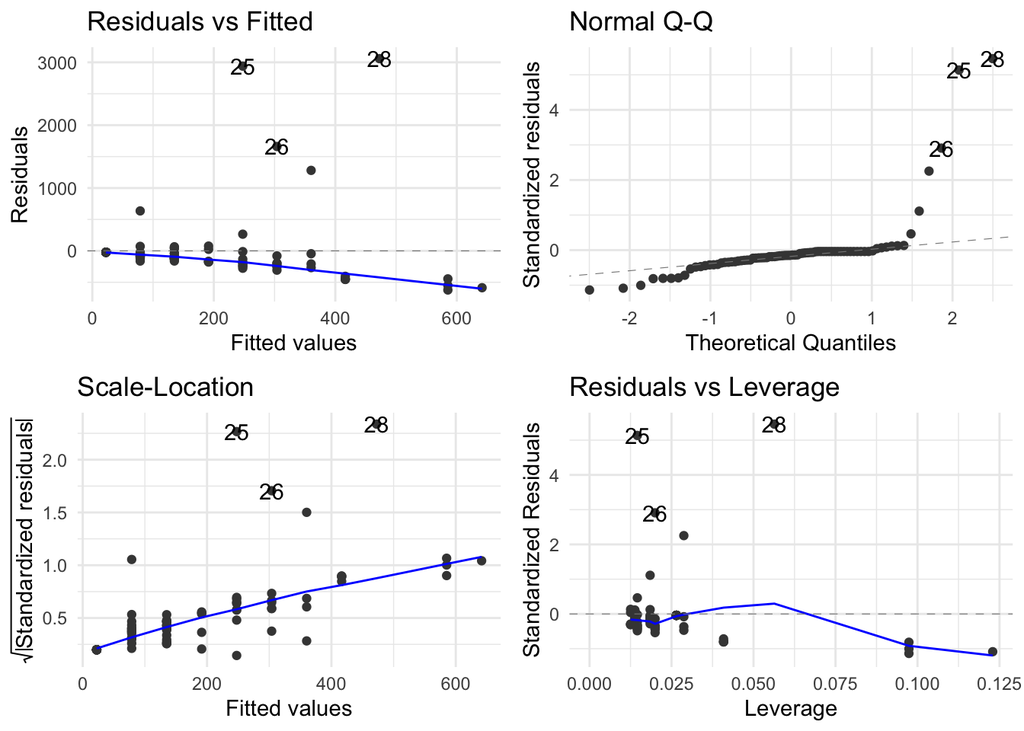

```r
# Linear regression:
reserve_cor_phi_lm <- lm(percentage_biomass_change_from_baseline ~ years_from_baseline, data = reserve_cor_phi)

#Model diagnostics:
# plot(ma_all_lm)
autoplot(reserve_cor_phi_lm) +
  theme_minimal()
```

**Residuals vs Fitted Plot (Top Left)**: There is slight downward curvature in the residuals, suggesting potential non-linearity. The spread of the residuals increases slightly at higher fitted values, indicating possible heteroscedasticity.

**Scale-Location Plot (Bottom Left)**: The upward-sloping blue line and increasing spread of points confirm heteroscedasticity, where the variability of residuals increases as fitted values rise.

**Summary**:

#### 3.3. Model Summary

```r
# Tables:
# Get the summary of the model
reserve_cor_phi_lm_summary <- summary(reserve_cor_phi_lm)
# Extract coefficients
coef_table_res_cor_phi <- as.data.frame(reserve_cor_phi_lm_summary$coefficients)
# Extract R-squared and Adjusted R-squared
r_squared_res_cor_phi <- reserve_cor_phi_lm_summary$r.squared
adj_r_squared_res_cor_phi <- reserve_cor_phi_lm_summary$adj.r.squared
# Extract F-statistic and p-value
f_statistic_res_cor_phi <- reserve_cor_phi_lm_summary$fstatistic[1]
p_value_res_cor_phi <- pf(f_statistic_res_cor_phi, reserve_cor_phi_lm_summary$fstatistic[2], reserve_cor_phi_lm_summary$fstatistic[3], lower.tail = FALSE)
# Extract Residual Standard Error
residual_res_cor_phi <- reserve_cor_phi_lm_summary$sigma

# Display coefficients in a neat table
kable(coef_table_res_cor_phi, caption = "Coefficients from the Linear Model")
```

Coefficients from the Linear Model

|  | Estimate | Std. Error | t value | Pr(>\|t\|) |
| --- | --- | --- | --- | --- |
| (Intercept) | 22.50630 | 93.84178 | 0.2398324 | 0.8110893 |
| years_from_baseline | 56.27912 | 23.61781 | 2.3829107 | 0.0196101 |

```r
# Create a summary statistics table
model_summary_res_cor_phi <- data.frame(
  Statistic = c("Residual Standard Error", "R-squared", "Adjusted R-squared", "F-statistic", "p-value"),
  Value = c(residual_res_cor_phi, r_squared_res_cor_phi, adj_r_squared_res_cor_phi, f_statistic_res_cor_phi, p_value_res_cor_phi)
)
# Display the model summary
kable(model_summary_res_cor_phi, caption = "Model Summary Statistics")
```

Model Summary Statistics

| Statistic | Value |
| --- | --- |
| Residual Standard Error | 576.5780617 |
| R-squared | 0.0678583 |
| Adjusted R-squared | 0.0559077 |
| F-statistic | 5.6782632 |
| p-value | 0.0196101 |

```r
#summary(reserve_cor_phi_lm)
```

**Coefficients**:

- **Intercept**: The intercept is 22.5, but its p-value is 0.81, indicating it is not statistically significant. This suggests the intercept does not meaningfully contribute to the model.
- `years_from_baseline`: The coefficient for `years_from_baseline` is 56.27, with a p-value of 0.01, indicating that the effect of years from baseline is statistically significant. This means that for each additional year from baseline, the percentage biomass change is expected to increase by 56.27%.

**Model Fit**:

- **Residual standard error**: The residual standard error is 576.57, suggesting considerable deviation of actual data points from the predicted values, indicating moderate model fit.
- **Multiple R-squared**: The R-squared value is 0.067, meaning that around 6.7% of the variance in percentage biomass change is explained by the years_from_baseline variable. This is quite low, indicating that the model does not explain much of the variability in biomass change.
- **Adjusted R-squared**: The adjusted R-squared is 0.055, which further confirms the low explanatory power of the model.
- **F-statistic:** The F-statistic is 5.67 with a p-value of 0.019, indicating that the model as a whole is statistically significant, meaning that the `years_from_baseline` variable is a meaningful predictor in this model.

**Summary**: